# Sinais exponenciais de tempo discreto

Renato Naville Watanabe

## Exponencial real

Em sinais discretos a exponencial real é definida da seguinte maneira:

$$x[n] = Ae^{\beta n}$$

Embora a expressão acima esteja correta, para sinais de tempo discreto é comum definirmos $\alpha = e^\beta$. Com isso, temos:

$$x[n] = A\alpha^n$$

Com $\alpha$ e $A$ reais.

Note que se $\alpha > 1$, a sequência $x[n]$ sempre aumenta, como é possível ver no gráfico abaixo (com $A=1$ e $\alpha=1.5$):

```
<StemContainer object of 3 artists>
```

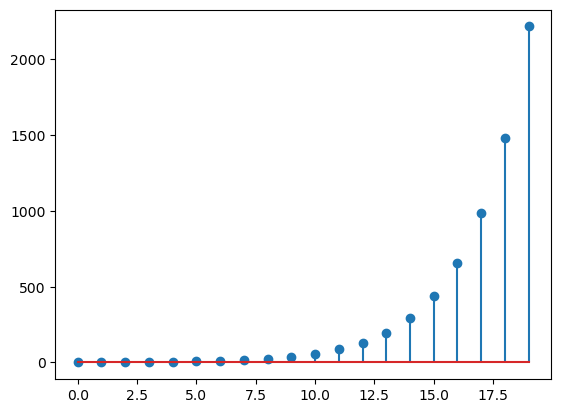

No caso de $0 < \alpha < 1$, a sequência $x[n]$ sempre diminui, como é possível ver no gráfico abaixo (com $A=1$ e $\alpha=0.5$):

```
<StemContainer object of 3 artists>
```

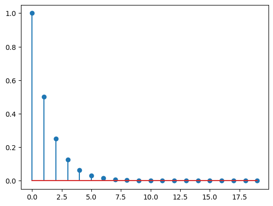

Para valores de $\alpha$ negativos, o sinal se torna oscilatório (quando $n$ é par, $x[n]$ é positivo, e quando $n$ é ímpar, $x[n]$ é negativo). Isso é possível de se observar no gráfico abaixo (com $A=1$ e $\alpha=-0.8$):

```
<StemContainer object of 3 artists>
```

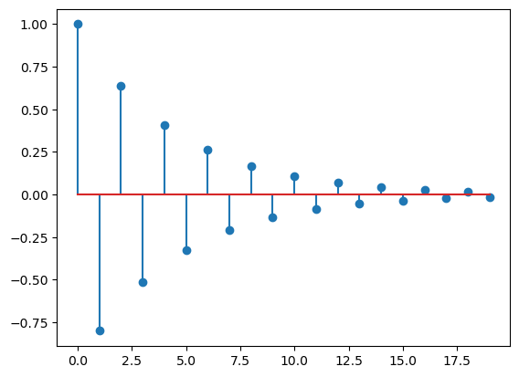

O sinal acima oscila e decai. Isso acontece porque $-1<\alpha<0$. Caso $\alpha < -1$, a amplitude do sinal aumentará, como visto abaixo (com $A = 1$ e $\alpha = -1.2$)

```
<StemContainer object of 3 artists>
```

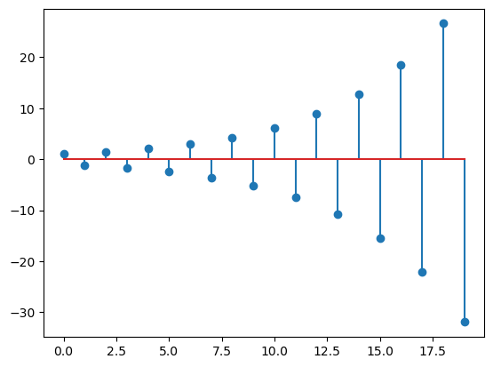

## Exponencial complexa

Da mesma forma que no caso contínuo, podemos definir um sinal com o expoente complexo:

$$x[n] = e^{j\omega_0 n}$$

Pela relação de Euler-Moivre, este sinal está totalmente relacionado com o cosseno:

$$x[n] = A\cos(\omega_0 n + \theta) = A\frac{e^{j(\omega_0 n + \theta)} + e^{-j(\omega_0 n + \theta)}}{2}$$

Abaixo, são mostrados diversos sinais cosseno, com diferentes frequências (as frequências sobem ao longo dos gráficos, da esquerda para a direita e de cima para baixo).

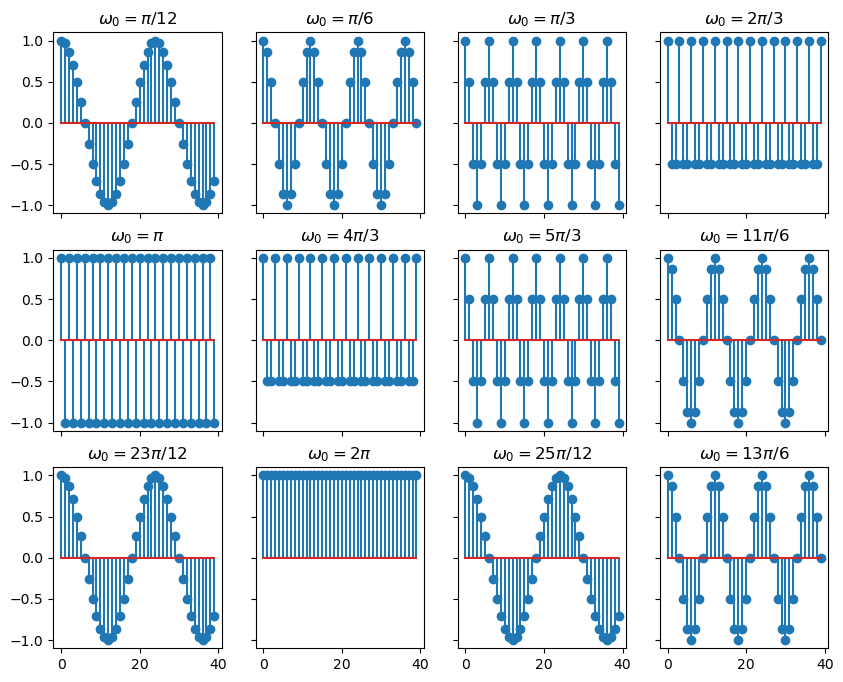

Uma outra diferença em relação ao cosseno (e exponencial complexa) de tempo contínuo é que nem sempre o sinal vai ser periódico. Para percebermos isso, vamos usar a definição de sinal periódico:

$$e^{j\omega_0 n} = e^{j\omega_0 (n+N)} = e^{j\omega_0 n}e^{j\omega_0 N}$$

A expressão acima só vai ter os dois lados iguais se:

$$ e^{j\omega_0 N} = 1$$

Isso só vai acontecer se existir algum $N$ inteiro que faça $\omega_0 N=2\pi$. Se existir, esse $N$ é que é o período fundamental do sinal. Mas, para existir, $\frac{\omega_0}{2\pi}$ precisa ser racional. Se essa divisão não for racional, o sinal não será periódico. Por exemplo, para:

$$x[n] = \cos(0.6n)$$

```
<StemContainer object of 3 artists>
```

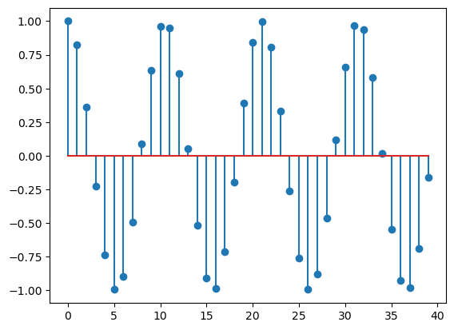

## Referências

- Oppenheim, M. e Willsky, S., Sistemas e Sinais, 2010
- Ulaby, FT e Yagle, AE, Signals & Systems: Theory and Applications, 2018, ss2.eecs.umich.edu
- Lathi, BP, Sinais e Sistemas Lineares, 2007